# S05 - Clasificacion supervisada

Juan Carlos Martínez-Ovando

Primavera 2017

# Clasificacion supervisada

## Maquina de soporte vectorial

### Teoria

Consideremos una clasificacion binaria con estimulos $X_i$ (*input space*) y atributos (a.k.a., *targets*, *clases*) $y_i = \in\{-1,1\}$.

```r
x1s <- c(.5,1,1,2,3,3.5,     1,3.5,4,5,5.5,6)
x2s <- c(3.5,1,2.5,2,1,1.2,  5.8,3,4,5,4,1)
ys <- c(rep(+1,6),          rep(-1,6))
my.data <- data.frame(x1=x1s, x2=x2s, type=as.factor(ys))
my.data
```

```
##     x1  x2 type
## 1  0.5 3.5    1
## 2  1.0 1.0    1
## 3  1.0 2.5    1
## 4  2.0 2.0    1
## 5  3.0 1.0    1
## 6  3.5 1.2    1
## 7  1.0 5.8   -1
## 8  3.5 3.0   -1
## 9  4.0 4.0   -1
## 10 5.0 5.0   -1
## 11 5.5 4.0   -1
## 12 6.0 1.0   -1
```

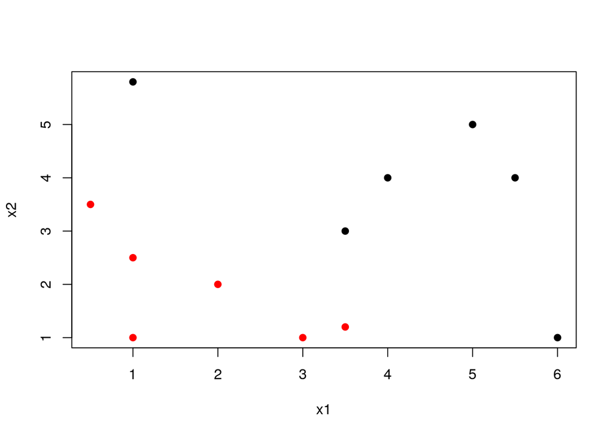

```r
plot(my.data[,-3],col=(ys+3)/2, pch=19); abline(h=0,v=0,lty=3)
```

Los modelos de Maquina de Soporte Vectorial (*Support Vector Machine* o SVM), se definen domo un modelo de regresion en el que el error es minimizado mediante la maximizacionde la *marginal* $\gamma$, ie., se obtienen mediante la distancia minima entre el hiperplano separando ambas clases y el punto minimo de cada clase mas cercanas (called *support vectors*).

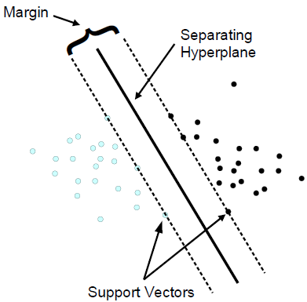

El hiperplano de separacion puede expresarse como
$$<\omega,x> + b = 0$$
donde $b$ es el parametro de sesgos y $\omega$ es el vector de pesos. Piensen en $<\omega,x>$ como el proyector lineal que vimos en las sesiones anteriores, $proj(\omega,x)$.

El parametro $\omega$ define la direccion de calculo al punto $x$ (en terminos del proyector $proj$ que elijamos) y, en el caso del proyector lineal, $\frac{b}{\|\omega\|}$ corresponde a la distancia perpendicular del hiperplano al origen. Vean el siguiente diagrama.

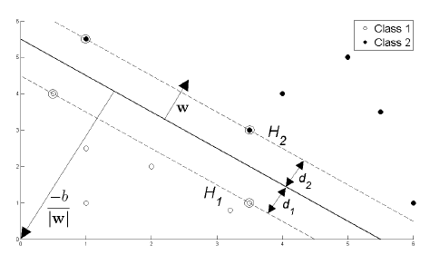

Definir la asignacion del `atributo` para el conjunto de estimulos $x_i$ correspondientes al $i$-esimo individuo se define como
$$D(x_i) = signal(proj(\omega,x_i) + b)$$
donde $D(\cdot)$ es una transformacion invariante bajo escalamiento positivo, i.e.
$$\begin{cases}
\omega & \rightarrow \lambda \omega
\nonumber \\
b & \rightarrow \lambda b,
\nonumber
\end{cases}$$

para un valor dijo de $\lambda > 0$ tal que *margin* tenga la distancia igual a $1$, de forma que
$$proj(\omega,x) + b = 1$$
o
$$proj(\omega,x) + b = -1,$$
para el vector de soportes (*support vectors*) de uno o de otro `atributos`. Esto define lo que se conoce como `hiperplano canonico` (o *canonical hyperplane*).

Si, por ejemplo, $x_1, x_2$ son dos `vectores soportes` (*support vectors*) de cada atributo, entonces definiendo la diferencia de los dos estimulos,
$$proj\left(\omega,(x_1 - x_2)\right) = 2.$$
Vean el diagrama.

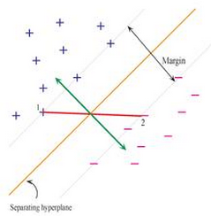

Ahora, si el vector $(x_1 - x_2)$ es proyectado (vector marcado en *rojo* en la figura anterior) sobre el hiperplano de separacion, i.e. con distancia $\frac{w}{|w|}$, obtenemos el doble de la distancia marginal,
$$proj \left( (x_1 - x_2),\frac{\omega}{\|\omega\|}\right) = \frac{proj\left(\omega,(x_1 - x_2)\right)}{\|\omega\|} = \frac{2}{\|\omega\|}.$$

De esta forma, la constante de normamilizacion es definida como $\gamma = \frac{1}{\|\omega\|}$. Asi, necesitamos maximizar $\frac{1}{\|\omega\|}$, minimizando $\|\omega\|$. Esto es equivalente a minimizar $\frac{1}{2}\|\omega\|^2$.

Esta minimizacion se raliza con restricciones, pues $\omega$ debe ser tal que las siguiente restriccion,
$$y_i (proj(\omega,x_i) + b) \geq 1,$$
se cumpla para todo $y_i$ y $x_i$. Esta restriccion esta definida en la clase de clasificacion de los datos originales.

La ecuacion alcanza el valor de $1$ para el `vector de soportes`. Para cualquier vecotor de estimulos $x$ se obtendra un valor mayor a $1$.

*NOTA: La optimizacion anterior se obtiene via multiplicadores de Langrage (revisen las referencias a este tema…)*

En el caso del proyector lineal, el procedimiento de optimizacion dara origen a los datos $\alpha_i$ tales que
$$\omega = \sum_i \alpha_i y_i x_i$$
$$\sum_i \alpha_i y_i = 0$$

donde si $x_i$ es un `support vector` entonces $\alpha_i>0$ siendo igual a $0$ en otro caso).

Definimos $S$ como el conjunto de indices de vectores de soporte,
$$b = \frac{1}{|S|} \sum_{s \in S} \Big( y_s - x_s . \sum_{m \in S} \alpha_m y_m x_m \Big)$$
siendo $b$ y $\omega$ los parametros que definen el hiperplano que define el modelo SVM.

### Implementacion

La implementacion de los modelos SVM la tomaremos de los paquetes `e1071` y `rpart` de R.

```
# Implementacion
install.packages("e1071")
install.packages("rpart")
# Datos
install.packages("mlbench")
```

#### A) Aprendizaje

```r
#rm(list=ls())
require("e1071")
```

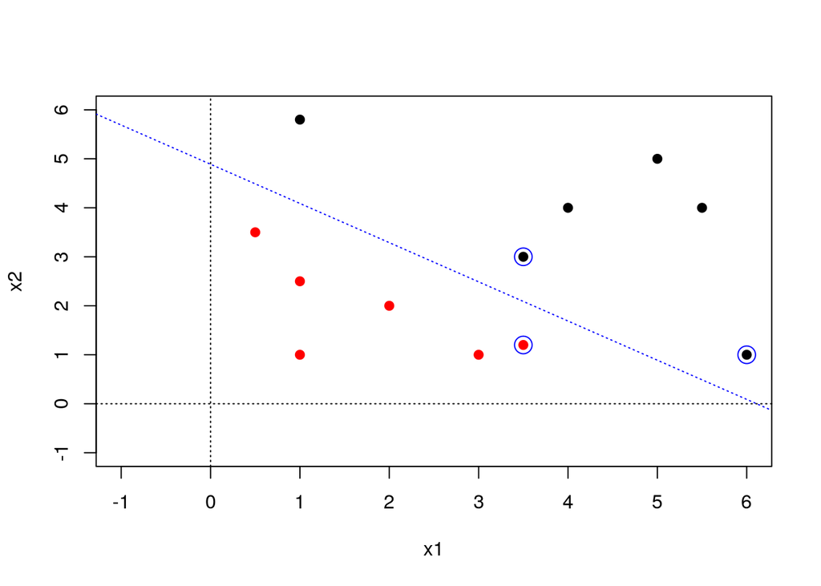

```r
svm.model <- svm(type ~ .,
                 data=my.data,
                 type='C-classification',
                 kernel='linear',scale=FALSE)

plot(my.data[,-3],
     col=(ys+3)/2,
     pch=19,
     xlim=c(-1,6), ylim=c(-1,6))
abline(h=0,v=0,lty=3)
# Mostramos los vectores de soporte
points(my.data[svm.model$index,c(1,2)],col="blue",cex=2)

# Parametros del hiperplano
w <- t(svm.model$coefs) %*% svm.model$SV
b <- -svm.model$rho

# Caso 2D: el hiperplano es la linea w[1,1]*x1 + w[1,2]*x2 + b = 0
abline(a=-b/w[1,2], b=-w[1,1]/w[1,2], col="blue", lty=3)
```

#### B) Prediccion

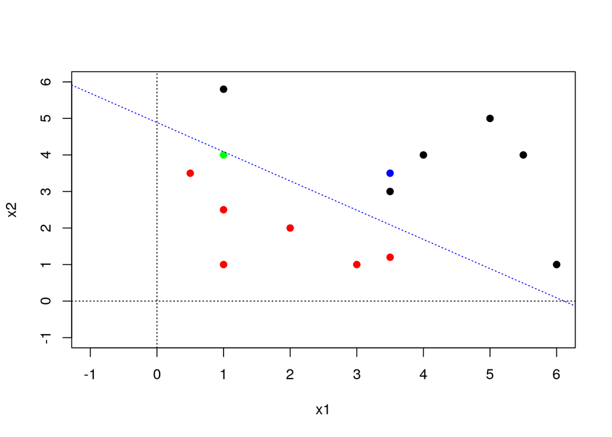

```r
observations <- data.frame(x1=c(1,3.5),x2=c(4,3.5))

plot(my.data[,-3],
     col=(ys+3)/2,
     pch=19,
     xlim=c(-1,6), ylim=c(-1,6))
abline(h=0,v=0,lty=3)
points(observations[1,], col="green", pch=19)
points(observations[2,], col="blue", pch=19)
abline(a=-b/w[1,2], b=-w[1,1]/w[1,2], col="blue", lty=3)
```

```r
predict(svm.model, observations)
```

```
##  1  2
##  1 -1
## Levels: -1 1
```

Las posibles variables de `estimulos` (o `covariables` o `support vectors`) son * `Sepal.Length`

- `Sepal.Width`
- `Petal.Length`
- `Petal.Width`

*Observen que en este caso, alguas coordenadas de los `estimulos` son separados.*

```r
data(iris)
head(iris)
```

```
##   Sepal.Length Sepal.Width Petal.Length Petal.Width Species
## 1          5.1         3.5          1.4         0.2  setosa
## 2          4.9         3.0          1.4         0.2  setosa
## 3          4.7         3.2          1.3         0.2  setosa
## 4          4.6         3.1          1.5         0.2  setosa
## 5          5.0         3.6          1.4         0.2  setosa
## 6          5.4         3.9          1.7         0.4  setosa
```

```r
summary(iris)
```

```
##   Sepal.Length  Sepal.Width   Petal.Length  Petal.Width        Species
##  Min.   :4.3   Min.   :2.0   Min.   :1.0   Min.   :0.1   setosa    :50
##  1st Qu.:5.1   1st Qu.:2.8   1st Qu.:1.6   1st Qu.:0.3   versicolor:50
##  Median :5.8   Median :3.0   Median :4.3   Median :1.3   virginica :50
##  Mean   :5.8   Mean   :3.1   Mean   :3.8   Mean   :1.2
##  3rd Qu.:6.4   3rd Qu.:3.3   3rd Qu.:5.1   3rd Qu.:1.8
##  Max.   :7.9   Max.   :4.4   Max.   :6.9   Max.   :2.5
```

```r
table(iris$Species)
```

```
##
##     setosa versicolor  virginica
##         50         50         50
```

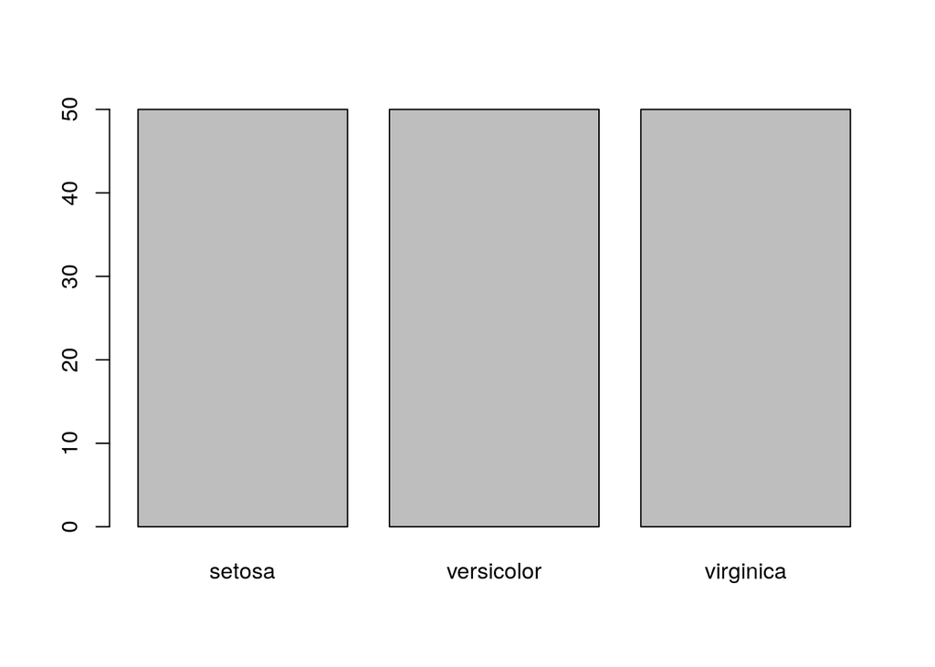

```r
plot(iris$Species)
```

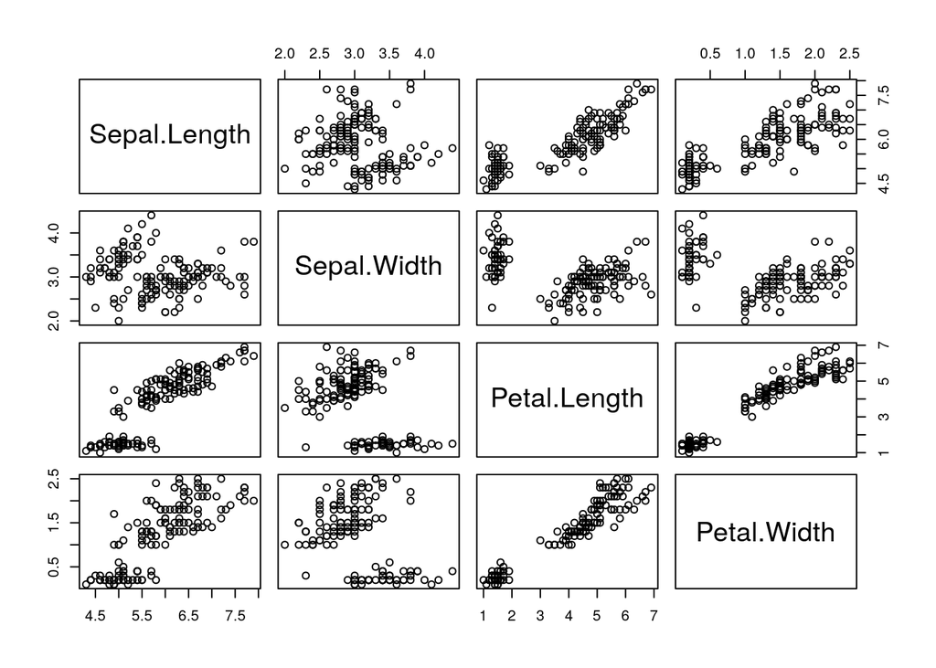

```r
plot(iris[, c("Sepal.Length","Sepal.Width","Petal.Length" , "Petal.Width")])
```

#### A) Aprendizaje

Las variables `Lenght` y `Width` son en este caso los `estimulos` o `vectores de soporte` (*support vectors*).

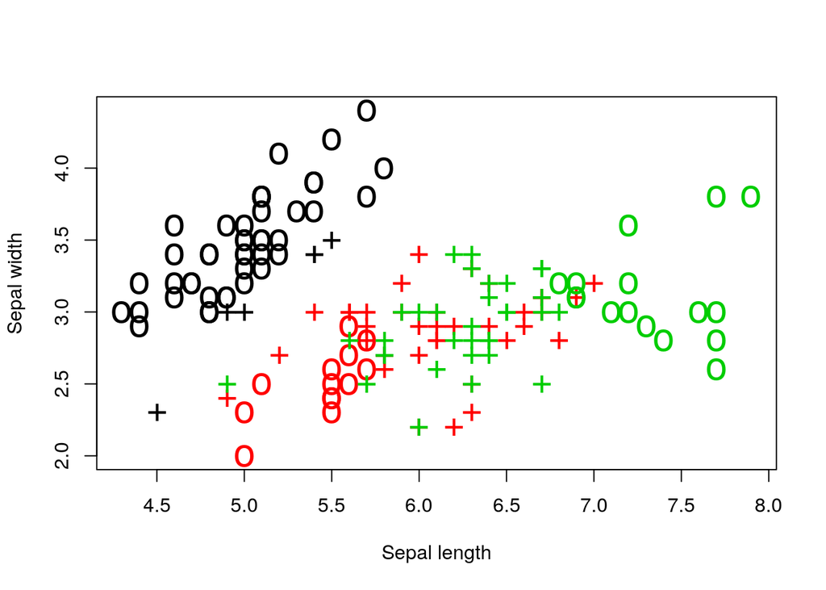

```r
svm.model <- svm(Species ~ Sepal.Length + Sepal.Width,
                 data = iris,
                 kernel = "linear")

plot(iris$Sepal.Length,
     iris$Sepal.Width, col = as.integer(iris[, 5]),
     pch = c("o","+")[1:150 %in% svm.model$index + 1], cex = 2,
     xlab = "Sepal length", ylab = "Sepal width")
```

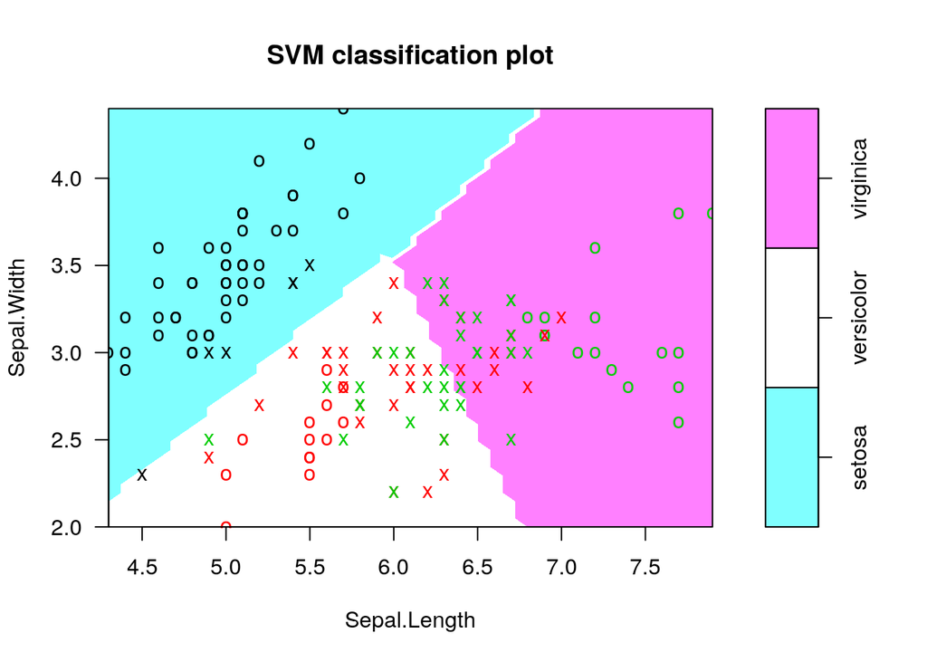

```r
plot(svm.model, iris,
     Sepal.Width ~ Sepal.Length,
     slice = list(sepal.width = 1, sepal.length = 2),
     main="")
```

#### B) Prediccion

```r
# Prediccion
svm.pred  <- predict(svm.model, iris[,-5])
# Iris - Matriz de confusion
table(pred = svm.pred, true = iris[,5])
```

```
##             true
## pred         setosa versicolor virginica
##   setosa         49          0         0
##   versicolor      1         38        15
##   virginica       0         12        35
```

### Referencias

- **Hastie** - Secciones 12.1-12.2
- **James et al** - Secciones 9.1-9.3
- **Alpaydin** - Secciones 10.8-10.9
- **Clark et al** - Seccion 5.4
- Cortes, C. & Vapnik, V. (1995). Support-vector network. Machine Learning, 20, 1–25.